# Abstract

Increased prevelance of fratricide in modern warfare brings significant risk to both mission success and soldier safety. Ths project explores how integrating real-time data from infantry units and weapon systems with machine learning can uncover patterns to detect events that predict and mitigate friendly fire incidents before they occur. A major obstacle when developing such models is the lack of publicly available data on fratricide incidents as well as the events leading to them. Using principles of IoT-based infrantry movement and weapon trajectory data, a synthetic dataset was created to design and train predictive models capable of identifying potential patterns leading to friendly fire incidents. The work below demonstrates the potential of applying predictive models to streamed data from sensors to provide actionable insights enhancing situational awareness, minimizing fratricide and supporting tactical decision making at the highest level.

## Initial Dependencies

```python
from sklearn.datasets import make_blobs
import matplotlib.pyplot as plt
import numpy as np
import pandas as pd
```

## Data Generation

### Simulation Parameters

```python
num_soldiers = 30
num_steps = 100
battlefield_size = 100  # meters
```

```python
# Create initial solider (personnel) positions to demonstrate dataset
def create_positions(num_soldiers):
  # Create gap between centers of friendly and hostile units
  distance_between_clusters = 20  # Minimum distance between clusters

  centers = [
    [distance_between_clusters, distance_between_clusters],
    [battlefield_size - distance_between_clusters, battlefield_size - distance_between_clusters],
  ]

  # Generate clustered positions
  Coordinates, teams = make_blobs(
    n_samples=num_soldiers,
    centers=centers,
    n_features=2,
    random_state=0,
    center_box=(0, battlefield_size),
    cluster_std=2.5  # Spread within sub-clusters
  )

  # Add noise to positions
  noise = np.random.normal(0, 2, Coordinates.shape)
  Coordinates += noise

  # Assign two of the sub-clusters to friendlies, the other two to hostiles
  teams = (Coordinates[:, 0] < battlefield_size / 2).astype(int)
  return Coordinates, teams
```

```python
Coordinates, teams = create_positions(num_soldiers)
print(Coordinates)
print(teams)
```

```
[[20.78904086 25.80053849]
 [82.06233169 80.57329125]
 [17.09176963 19.70145579]
 [76.56347182 76.60560717]
 [26.65797044 17.00279666]
 [21.30838606 15.25228879]
 [19.55765639 21.82237413]
 [24.97176183 21.21376048]
 [74.96921441 78.24133288]
 [79.01340392 80.20767665]
 [21.71495111 18.94720361]
 [20.85736815 16.83790913]
 [81.29883213 80.76147792]
 [21.89557821 17.09479397]
 [22.09181885 25.34854516]
 [11.47484846 20.63593764]
 [19.74764224 19.24427335]
 [75.32263571 82.68081584]
 [80.85454813 76.64384293]
 [78.92128656 78.81183547]
 [78.52600078 80.19874021]
 [23.36426008 24.74621088]
 [83.88123275 83.48011752]
 [74.76396294 78.80427777]
 [20.52939021 17.75568959]
 [82.33457913 81.46693628]
 [79.57623037 81.18157704]
 [24.9721661  17.05173413]
 [80.11340993 81.29317687]
 [74.68301331 83.46505798]]
[1 0 1 0 1 1 1 1 0 0 1 1 0 1 1 1 1 0 0 0 0 1 0 0 1 0 0 1 0 0]
```

```python
# Assign generated coordinates to friendly units and hostile units
def assign_units(Coordinates, teams):
  personnel = pd.DataFrame({'soldier_id':[], 'affiliation':[], 'x':[], 'y':[], 'z':[]})
  for idx, team in enumerate(teams):
    if team == 1:
      unit = 'Friendly'
    else:
      unit = 'Hostile'
    information = {'soldier_id':f'S{idx+1:03}', 'affiliation':unit, 'x':Coordinates[idx][0], 'y':Coordinates[idx][1], 'z':0.0}
    personnel.loc[len(personnel)]=information
  return personnel
```

```python
personnel = assign_units(Coordinates, teams)
personnel.head()
```

|  | soldier_id | affiliation | x | y | z |
| --- | --- | --- | --- | --- | --- |
| 0 | S001 | Friendly | 20.789041 | 25.800538 | 0.0 |
| 1 | S002 | Hostile | 82.062332 | 80.573291 | 0.0 |
| 2 | S003 | Friendly | 17.091770 | 19.701456 | 0.0 |
| 3 | S004 | Hostile | 76.563472 | 76.605607 | 0.0 |
| 4 | S005 | Friendly | 26.657970 | 17.002797 | 0.0 |

### Visualize Initial Positions

Inspired by Developing Combat Behavior Through Reinforcement Learning [1]. Personnel depicted in accordance to US Marine Corps Reference Publication 5-12A, Operational Terms and Graphics [2].

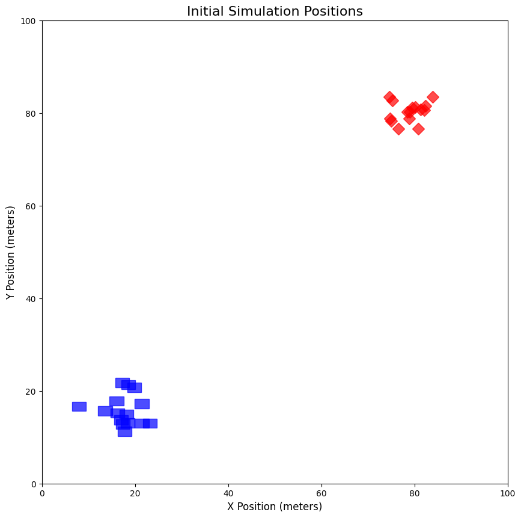

```python
plt.figure(figsize=(10, 10))
plt.xlim(0, battlefield_size)
plt.ylim(0, battlefield_size)

# Friendly units: blue rectangles
for _, row in personnel[personnel['affiliation'] == 'Friendly'].iterrows():
  plt.gca().add_patch(plt.Rectangle((row['x'] - 5, row['y'] - 5), 3, 2, color='blue', alpha=0.7))

# Hostile units: red diamonds
for _, row in personnel[personnel['affiliation'] == 'Hostile'].iterrows():
  plt.plot(row['x'], row['y'], marker='D', color='red', markersize=10, alpha=0.7)

# Labels and grid
plt.title("Initial Simulation Positions", fontsize=16)
plt.xlabel("X Position (meters)", fontsize=12)
plt.ylabel("Y Position (meters)", fontsize=12)
plt.show()
```

### Add Simulated Weapon Data

```python
def compute_muzzle_orientation(row):
  # Unnecessary to calculate hostile weapon data, added for additional information
  friendly_centroid = personnel[personnel['affiliation'] == 'Friendly'][['x', 'y']].mean().values
  hostile_centroid = personnel[personnel['affiliation'] == 'Hostile'][['x', 'y']].mean().values

  if row['affiliation'] == 'Friendly':
      target = hostile_centroid
  else:
      target = friendly_centroid

  # Azimuth (horizontal plane orientation)
  dx, dy = target[0] - row['x'], target[1] - row['y']
  azimuth = np.degrees(np.arctan2(dy, dx)) % 360

  # Add noise to simulated positions
  azimuth += np.random.uniform(-10, 10)

  # Elevation (vertical plane orientation)
  elevation = np.random.uniform(-10, 45)

  return azimuth, elevation
```

```python
# Apply synthetic muzzle orientations to personnel
personnel[['muzzle_azimuth', 'muzzle_elevation']] = personnel.apply(
  lambda row: pd.Series(compute_muzzle_orientation(row)), axis=1
)
```

```python
print(personnel.head())
```

```
  soldier_id affiliation          x          y    z  muzzle_azimuth  \
0       S001    Friendly  20.789041  25.800538  0.0       43.029472
1       S002     Hostile  82.062332  80.573291  0.0      227.142052
2       S003    Friendly  17.091770  19.701456  0.0       48.857100
3       S004     Hostile  76.563472  76.605607  0.0      231.441956
4       S005    Friendly  26.657970  17.002797  0.0       46.492281

   muzzle_elevation
0         14.997804
1         21.277765
2         -7.222965
3         27.742824
4          3.007354
```

```python
# Note: Calculating 3D vector from two angles
# where alpha is angle on horizontal plane (azimuth)
# and beta is angle on vertical plane (elevation)
# x = Math.cos(alpha) * Math.cos(beta);
# z = Math.sin(alpha) * Math.cos(beta);
# y = Math.sin(beta);

def muzzle_vector(azimuth, elevation):
  azimuth_rad = np.radians(azimuth)
  elevation_rad = np.radians(elevation)
  return np.array([
      np.cos(elevation_rad) * np.cos(azimuth_rad),
      np.cos(elevation_rad) * np.sin(azimuth_rad),
      np.sin(elevation_rad)
  ])
```

```python
# Calculate if there are friendlies in line of fire
def line_of_fire(row, personnel, angle_threshold=10):
  if row['affiliation'] == 'Hostile':  # Only check for friendly fire
    return False

  # Muzzle vector
  mv = muzzle_vector(row['muzzle_azimuth'], row['muzzle_elevation'])
  origin = np.array([row['x'], row['y'], row['z']])

  # Friendly positions
  friendlies = personnel[personnel['affiliation'] == 'Friendly']
  friendly_positions = friendlies[['x', 'y', 'z']].values
  vectors_to_friendlies = friendly_positions - origin

  # Normalize for unit vector
  with np.errstate(divide='ignore',invalid='ignore'):
    vectors_to_friendlies_norm = vectors_to_friendlies / np.linalg.norm(vectors_to_friendlies, axis=1, keepdims=True)

  # Compute angles
  dot_products = np.dot(vectors_to_friendlies_norm, mv)
  angles = np.degrees(np.arccos(np.clip(dot_products, -1.0, 1.0)))

  # Check if any angle is below the threshold
  return np.any(angles < angle_threshold)
```

```python
# Note: soldier, friendly should be rows containing all relevant information
def friendly_in_line_of_fire(soldier, friendly, azimuth_threshold=10, elevation_threshold=5):
  # Distance vector between soldier/friendly
  dx = friendly['x'] - soldier['x']
  dy = friendly['y'] - soldier['y']
  dz = friendly['z'] - soldier['z']
  distance = np.sqrt(dx**2 + dy**2 + dz**2)

  # Muzzle angle to friendly
  azimuth_to_friendly = (np.degrees(np.arctan2(dy,dx)) + 360) % 360
  elevation_to_friendly = np.degrees(np.arctan2(dz, distance))

  azimuth_diff = abs(azimuth_to_friendly - soldier['muzzle_azimuth'])
  elevation_diff = abs(elevation_to_friendly - soldier['muzzle_elevation'])

  return azimuth_diff <= azimuth_threshold and elevation_diff <= elevation_threshold
```

```python
personnel['friendly_in_fire'] = personnel.apply(
    lambda row: line_of_fire(row, personnel), axis=1
)
personnel
```

|  | soldier_id | affiliation | x | y | z | muzzle_azimuth | muzzle_elevation | friendly_in_fire |
| --- | --- | --- | --- | --- | --- | --- | --- | --- |
| 0 | S001 | Friendly | 20.789041 | 25.800538 | 0.0 | 43.029472 | 14.997804 | False |
| 1 | S002 | Hostile | 82.062332 | 80.573291 | 0.0 | 227.142052 | 21.277765 | False |
| 2 | S003 | Friendly | 17.091770 | 19.701456 | 0.0 | 48.857100 | -7.222965 | True |
| 3 | S004 | Hostile | 76.563472 | 76.605607 | 0.0 | 231.441956 | 27.742824 | False |
| 4 | S005 | Friendly | 26.657970 | 17.002797 | 0.0 | 46.492281 | 3.007354 | False |
| 5 | S006 | Friendly | 21.308386 | 15.252289 | 0.0 | 42.234791 | 0.421748 | False |
| 6 | S007 | Friendly | 19.557656 | 21.822374 | 0.0 | 42.508900 | 22.759775 | False |
| 7 | S008 | Friendly | 24.971762 | 21.213760 | 0.0 | 51.966897 | 28.656915 | False |
| 8 | S009 | Hostile | 74.969214 | 78.241333 | 0.0 | 232.309692 | 16.089187 | False |
| 9 | S010 | Hostile | 79.013404 | 80.207677 | 0.0 | 233.196350 | -9.016296 | False |
| 10 | S011 | Friendly | 21.714951 | 18.947204 | 0.0 | 55.684816 | 28.388308 | False |
| 11 | S012 | Friendly | 20.857368 | 16.837909 | 0.0 | 41.023506 | 32.058939 | False |
| 12 | S013 | Hostile | 81.298832 | 80.761478 | 0.0 | 215.926815 | 16.471989 | False |
| 13 | S014 | Friendly | 21.895578 | 17.094794 | 0.0 | 56.234518 | 10.965655 | False |
| 14 | S015 | Friendly | 22.091819 | 25.348545 | 0.0 | 35.477350 | 12.415690 | False |
| 15 | S016 | Friendly | 11.474848 | 20.635938 | 0.0 | 40.990457 | 28.485050 | False |
| 16 | S017 | Friendly | 19.747642 | 19.244273 | 0.0 | 52.248014 | 40.299943 | False |
| 17 | S018 | Hostile | 75.322636 | 82.680816 | 0.0 | 230.180118 | 27.543381 | False |
| 18 | S019 | Hostile | 80.854548 | 76.643843 | 0.0 | 224.979455 | 28.678549 | False |
| 19 | S020 | Hostile | 78.921287 | 78.811835 | 0.0 | 222.315085 | -2.869993 | False |
| 20 | S021 | Hostile | 78.526001 | 80.198740 | 0.0 | 221.551912 | -2.698515 | False |
| 21 | S022 | Friendly | 23.364260 | 24.746211 | 0.0 | 42.759209 | 34.257892 | False |
| 22 | S023 | Hostile | 83.881233 | 83.480118 | 0.0 | 231.202560 | 39.704180 | False |
| 23 | S024 | Hostile | 74.763963 | 78.804278 | 0.0 | 233.320093 | -3.656984 | False |
| 24 | S025 | Friendly | 20.529390 | 17.755690 | 0.0 | 49.326565 | 11.350185 | False |
| 25 | S026 | Hostile | 82.334579 | 81.466936 | 0.0 | 217.652582 | 13.690249 | False |
| 26 | S027 | Hostile | 79.576230 | 81.181577 | 0.0 | 232.784809 | 42.963322 | False |
| 27 | S028 | Friendly | 24.972166 | 17.051734 | 0.0 | 55.726236 | -9.733774 | False |
| 28 | S029 | Hostile | 80.113410 | 81.293177 | 0.0 | 232.002322 | 42.359118 | False |
| 29 | S030 | Hostile | 74.683013 | 83.465058 | 0.0 | 230.881813 | 2.680516 | False |

```python
def plot_personnel_positions(personnel):
  plt.figure(figsize=(10, 10))
  plt.xlim(0, battlefield_size)
  plt.ylim(0, battlefield_size)

  # Friendly units: blue rectangles
  for _, row in personnel[personnel['affiliation'] == 'Friendly'].iterrows():
    # plt.plot(row['x'], row['y'], marker='s', color='blue', markersize=10, alpha=0.7)
    plt.gca().add_patch(plt.Rectangle((row['x'] - 1, row['y'] - 1), 3, 2, color='blue', alpha=0.7))

  # Hostile units: red diamonds
  for _, row in personnel[personnel['affiliation'] == 'Hostile'].iterrows():
    plt.plot(row['x'], row['y'], marker='D', color='red', markersize=10, alpha=0.7)

  # Muzzle orientation
  for _, row in personnel.iterrows():
    if row['friendly_in_fire']:
      color='red'
    else:
      color='black'

    # Ignores hostile weapon trajectories
    if row['affiliation'] == 'Friendly':
      dx = 20 * np.cos(np.radians(row['muzzle_azimuth']))
      dy = 20 * np.sin(np.radians(row['muzzle_azimuth']))
      plt.arrow(row['x'], row['y'], dx, dy, color=color, head_width=.5, alpha=0.7)

  # Labels and grid
  plt.title("Initial Simulation Positions", fontsize=16)
  plt.xlabel("X Position (meters)", fontsize=12)
  plt.ylabel("Y Position (meters)", fontsize=12)
  plt.show()
```

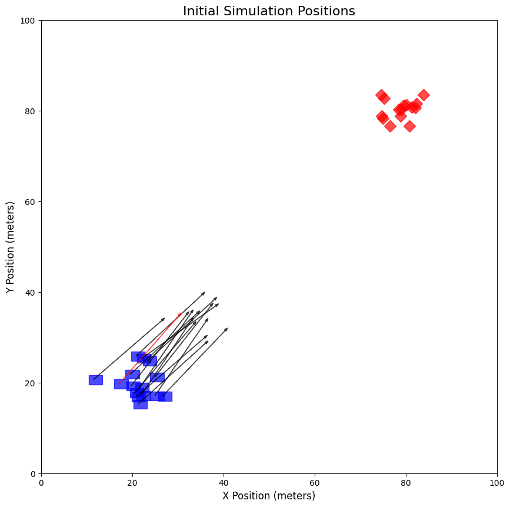

```python
plot_personnel_positions(personnel)
```

```python
from mpl_toolkits.mplot3d import Axes3D

def plot_personnel_positions_3d(personnel, view_elevation, view_azimuth):
  fig = plt.figure(figsize=(12, 10))
  ax = fig.add_subplot(111, projection='3d')

  # Plot limits
  ax.set_xlim(0, battlefield_size)
  ax.set_ylim(0, battlefield_size)
  ax.set_zlim(0, 50)  # Elevation in meters

  # View angle
  ax.view_init(elev=view_elevation, azim=view_azimuth)  # Change angles here

  # Friendly units: blue squares
  for _, row in personnel[personnel['affiliation'] == 'Friendly'].iterrows():
    ax.scatter(row['x'], row['y'], row['z'], color='blue', marker='s', s=50, label="Friendly" if 'Friendly' not in locals() else "")
    ax.text(row['x'], row['y'], row['z'], 'Friendly', color='blue', fontsize=8)

  # Hostile units: red diamonds
  for _, row in personnel[personnel['affiliation'] == 'Hostile'].iterrows():
    ax.scatter(row['x'], row['y'], row['z'], color='red', marker='D', s=50, label="Hostile" if 'Hostile' not in locals() else "")
    ax.text(row['x'], row['y'], row['z'], 'Hostile', color='red', fontsize=8)

  # Muzzle orientation: azimuth in xy-plane, elevation in yz-plane
  for _, row in personnel.iterrows():
    if row['affiliation'] == 'Friendly':  # Only plot friendly units' trajectories
      # Vector components
      muzzle_azimuth_rad = np.radians(row['muzzle_azimuth'])  # Azimuth angle in radians
      muzzle_elevation_rad = np.radians(row['muzzle_elevation'])  # Elevation angle in radians
      magnitude = 20  # Length of the trajectory vector

      # Compute dx, dy, dz for the 3D vector
      dx = magnitude * np.cos(muzzle_elevation_rad) * np.cos(muzzle_azimuth_rad)  # Horizontal component (X)
      dy = magnitude * np.cos(muzzle_elevation_rad) * np.sin(muzzle_azimuth_rad)  # Horizontal component (Y)
      dz = magnitude * np.sin(muzzle_elevation_rad)  # Vertical component (Z)

      # Color trajectory vector based on friendly_in_fire
      color = 'red' if row['friendly_in_fire'] else 'black'
      ax.quiver(row['x'], row['y'], row['z'], dx, dy, dz, color=color, arrow_length_ratio=0.1, linewidth=1.5)

  # Labels and grid
  ax.set_title("3D Battlefield Simulation: Positions and Weapon Trajectories", fontsize=14)
  ax.set_xlabel("X Position (meters)", fontsize=12)
  ax.set_ylabel("Y Position (meters)", fontsize=12)
  ax.set_zlabel("Elevation (meters)", fontsize=12)

  plt.show()
```

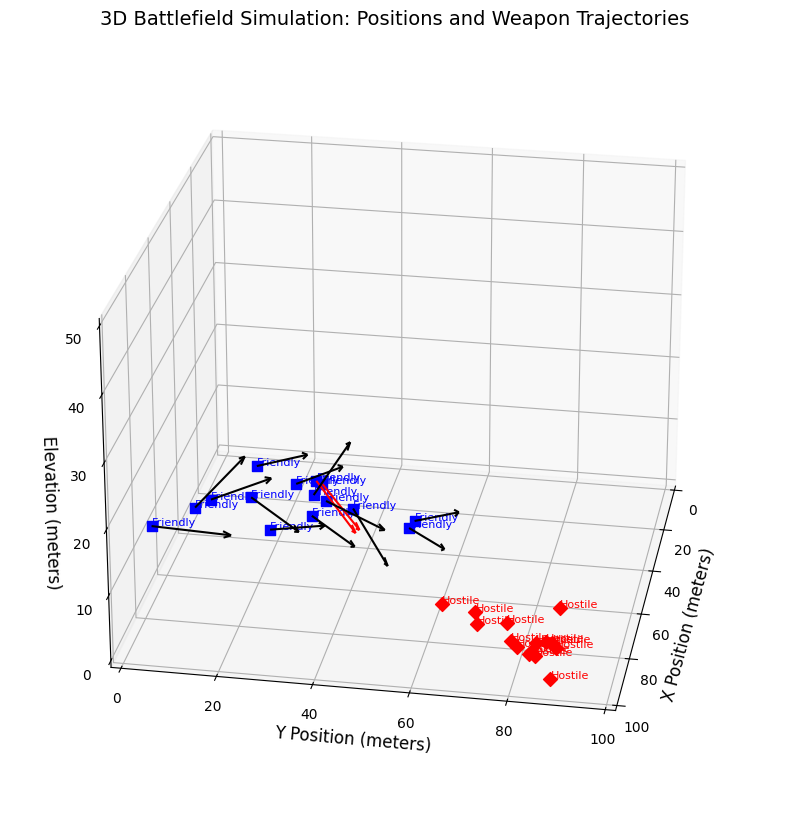

```python
plot_personnel_positions_3d(personnel, 25, 10)
```

### Simulate Random Movement

```python
# Simulates movement in x,y plane, simplified to be within movement range
# Assumes no obstacles and flat elevation
def simulate_movement(personnel, time_steps, movement_range):
  time_series_data = []
  for t in range(time_steps):
    # Random movement on plane
    dx = np.random.uniform(-movement_range, movement_range, size=len(personnel))
    dy = np.random.uniform(-movement_range, movement_range, size=len(personnel))
    dz = np.random.uniform(0, 1, size=len(personnel))  # Stance variation

    # Update positions
    personnel['x'] += dx
    personnel['y'] += dy
    personnel['z'] = dz  # Stance variation
    personnel['time'] = t  # Time step

    # Save state
    personnel[['muzzle_azimuth', 'muzzle_elevation']] = personnel.apply(
      lambda row: pd.Series(compute_muzzle_orientation(row)), axis=1
    )
    personnel['friendly_in_fire'] = personnel.apply(
      lambda row: line_of_fire(row, personnel), axis=1
    )
    time_series_data.append(personnel.copy())
  return pd.concat(time_series_data, ignore_index=True)

# Simulate
time_series_data = simulate_movement(personnel, time_steps=10, movement_range=5)
```

```python
from matplotlib.animation import FuncAnimation
from IPython.display import HTML

plt.ioff()

def update(frame):
  plt.cla()
  plt.xlim(0, battlefield_size)
  plt.ylim(0, battlefield_size)

  current_time_data = time_series_data[time_series_data['time'] == frame]

  # Friendly units: blue rectangles
  for _, row in current_time_data[current_time_data['affiliation'] == 'Friendly'].iterrows():
    plt.gca().add_patch(plt.Rectangle((row['x'] - 1, row['y'] - 1), 3, 2, color='blue', alpha=0.7))

  # Hostile units: red diamonds
  for _, row in current_time_data[current_time_data['affiliation'] == 'Hostile'].iterrows():
    plt.plot(row['x'], row['y'], marker='D', color='red', markersize=10, alpha=0.7)

  # Muzzle orientation
  for _, row in current_time_data.iterrows():
    if row['friendly_in_fire']:
      color = 'red'
    else:
      color = 'black'

    if row['affiliation'] == 'Friendly':  # Only show friendly fire trajectories
      dx = 20 * np.cos(np.radians(row['muzzle_azimuth']))
      dy = 20 * np.sin(np.radians(row['muzzle_azimuth']))
      plt.arrow(row['x'], row['y'], dx, dy, color=color, head_width=0.5, alpha=0.7)

  plt.title(f"Battlefield Positions at Time {frame}", fontsize=16)
  plt.xlabel("X Position (meters)", fontsize=12)
  plt.ylabel("Y Position (meters)", fontsize=12)

# Animation
fig = plt.figure(figsize=(8, 8))
anim = FuncAnimation(fig, update, frames=range(10), interval=1000)  # 10 frames, 1-second interval

HTML(anim.to_jshtml())
```

[figure not shown]

## Early Fratricide Warning Model

```python
import torch
from torch.utils.data import Dataset, DataLoader
from sklearn.utils import resample
```

```python
if torch.cuda.is_available():
    DEVICE = 'cuda'
elif torch.mps.is_available():
    DEVICE = 'mps'
else:
    DEVICE = 'cpu'
print(DEVICE)
```

```
cuda
```

### Simulated Sequential Dataset

```python
# Synthetic dataset using principles and functions established above
class SimulatedDataset(Dataset):
  def __init__(self, num_personnel = 50, timesteps=100, proximity_thresh = 10):
    self.data = []
    self.proximity_thresh = proximity_thresh
    # Create initial personnel positions
    Coord, teams = create_positions(num_personnel)
    soldiers = assign_units(Coord, teams)

    time_series_data = simulate_movement(soldiers, timesteps, movement_range=5)

    time_series_data['nearby_count'] = 0
    time_series_data['friendly_in_fire'] = 0

    # Compute context of nearby personnel
    for t in range(timesteps):
      curr_time = time_series_data[time_series_data['time']==t]

      for idx, soldier in curr_time.iterrows():
        if soldier['affiliation'] == 'Hostile':
          continue

        distances = np.sqrt(
            (curr_time['x'] - soldier['x']) ** 2 +
            (curr_time['y'] - soldier['y']) ** 2 +
            (curr_time['z'] - soldier['z']) ** 2
        )

        # Find personnel nearby within the threshold
        nearby = curr_time[(distances <= self.proximity_thresh) & (curr_time['soldier_id'] != soldier['soldier_id'])]
        time_series_data.loc[idx, 'nearby_count'] = len(nearby[nearby['affiliation'] == 'Friendly'])

        # Classify if any friendlies are in firing trajectory
        personnel['friendly_in_fire'] = personnel.apply(
          lambda row: line_of_fire(row, personnel), axis=1
        )

        for _, friendly in nearby[nearby['affiliation'] == 'Friendly'].iterrows():
          if friendly_in_line_of_fire(soldier, friendly):
            time_series_data.loc[idx, 'friendly_in_fire'] = 1
            break

    # create input/output encoded pairs for dataset
    for _, row in time_series_data.iterrows():
      input = row[['x','y','z','muzzle_azimuth','muzzle_elevation','nearby_count']].to_numpy(dtype=np.float32)
      input_enc = torch.tensor(input, dtype=torch.float32)
      output_enc = torch.tensor(np.array([row['friendly_in_fire']]), dtype=torch.float32)
      self.data.append((input_enc, output_enc))

  def __len__(self):
    return len(self.data)

  def __getitem__(self, idx):
    input_enc, output_enc = self.data[idx]
    return input_enc, output_enc
```

```python
data = SimulatedDataset()
print(len(data))
```

```
5000
```

```python
i, o = data[0]
i
```

```
tensor([ 83.6456,  76.7416,   0.3542, 224.1004,  32.3190,   0.0000])
```

```python
o
```

```
tensor([0.])
```

```python
print(i.shape)
print(o.shape)
```

```
torch.Size([6])
torch.Size([1])
```

### Model Definition

Simple feedforward neural network (an MLP) will be used to predict fratricide based off a single-moment snapshot of personnel positions and weapon trajectories.

When expanding to time-series data (e.g. real-time data streaming of a unit on the field), a reccurant neural network (an LSTM) can be used to predict fratricide by analyzing how positions and weapon trajectories evolve over time.

```python
import torch.nn as nn

class FratricideMLP(nn.Module):
  def __init__(self):
    super(FratricideMLP, self).__init__()
    self.model = nn.Sequential(
        # input size is 6, representing [pos_x, pos_y, pos_z, muzzle_azimuth, muzzle_elevation, nearby_count]
        nn.Linear(6,32), # Input layer to hidden layer
        nn.ReLU(),
        nn.Dropout(0.2), # Dropout layer to reduce overfitting
        nn.Linear(32,32),  # Hidden layer to hidden layer
        nn.ReLU(),
        nn.Dropout(0.2),
        nn.Linear(32,1), # Hidden to output layer
        nn.Sigmoid() # Binary classification
    )

  def forward(self, x):
    return self.model(x)
```

### Model Training

```python
from torch.utils.data import random_split

train_size = int(0.8*len(data))
test_size = len(data)-train_size

# Split dataset into train and test sets  (80/20)
train_data, test_data = random_split(data, [train_size, test_size])

train_loader = DataLoader(train_data, batch_size=32, shuffle=True)
test_loader = DataLoader(test_data, batch_size=32, shuffle=True)
```

```python
from imblearn.over_sampling import SMOTE

# Address class imbalance of non-friendly-fire to friendly-fire samples using SMOTE
train_features = []
train_labels = []

for feature, label in train_data:
  train_features.append(feature.numpy())
  train_labels.append(label.numpy())

# Converted for SMOTE
X_train = np.array(train_features)
y_train = np.array(train_labels)

smote = SMOTE(sampling_strategy=0.5)  # Oversample by 50% of majority class
X_resampled, y_resampled = smote.fit_resample(X_train, y_train)

X_resampled_tensor = torch.tensor(X_resampled, dtype=torch.float32)
y_resampled_tensor = torch.tensor(y_resampled, dtype=torch.float32)
```

```python
# Dataset using resampled data
class ResampledDataset(Dataset):
    def __init__(self, X, y):
        self.inputs = X
        self.outputs = y

    def __len__(self):
        return len(self.inputs)

    def __getitem__(self, idx):
        return self.inputs[idx], self.outputs[idx]
```

```python
# Create training set from resampled data
train_resampled_data = ResampledDataset(X_resampled_tensor, y_resampled_tensor)
train_loader = DataLoader(train_resampled_data, batch_size=32, shuffle=True)
```

```python
model = FratricideMLP().to(DEVICE)
```

```python
model(i.to(DEVICE)).shape
```

```
torch.Size([1])
```

```python
from torch.nn import BCELoss
from sklearn.metrics import accuracy_score, precision_score, recall_score, f1_score

# Hyperparameters
# Input dim: 6, Hidden dim: 32, Output dim: 1, Batch size: 16
LEARNING_RATE = 1e-03
num_epochs = 10

loss_function = nn.BCELoss()
optimizer = torch.optim.AdamW(params=model.parameters(), lr=LEARNING_RATE)

for epoch in range(num_epochs):
  tr_loss = 0
  nb_tr_examples, nb_tr_steps = 0, 0
  total_correct, total_predictions = 0, 0

  # Put model in training mode
  model.train()

  for idx, batch in enumerate(train_loader):
    inputs,targets = batch
    inputs = inputs.to(DEVICE)
    targets = targets.to(DEVICE)

    # Forward pass of model
    predictions = model(inputs)
    loss = loss_function(predictions.squeeze(), targets.squeeze())
    tr_loss += loss.item()

    nb_tr_steps += 1
    nb_tr_examples += targets.size(0)

    # Calculate accuracy
    binary_predictions = (predictions.squeeze() > 0.5).float()
    total_correct += (binary_predictions == targets.squeeze()).sum().item()
    total_predictions += targets.size(0)

    if idx % 100==0:
      curr_avg_loss = tr_loss/nb_tr_steps
      print(f"Current average loss: {curr_avg_loss}")
      # print(f'Binary preds: {binary_predictions}')
      # print(f'targets: {targets}')

    # Backward pass to update parameters
    optimizer.zero_grad()
    loss.backward()
    optimizer.step()

  epoch_loss = tr_loss / nb_tr_steps
  epoch_accuracy = total_correct / total_predictions if total_predictions != 0 else 0  # Avoid division by zero
  print(f'Training loss epoch {epoch+1}/{num_epochs}: {epoch_loss:.4f}')
  print(f'Average accuracy epoch {epoch+1}/{num_epochs}: {epoch_accuracy:.4f}')
```

```
Current average loss: 0.8640146255493164
Current average loss: 0.5607172634341929
Training loss epoch 1/10: 0.4843
Average accuracy epoch 1/10: 0.7281
Current average loss: 0.5869203805923462
Current average loss: 0.33997443657700377
Training loss epoch 2/10: 0.3183
Average accuracy epoch 2/10: 0.8456
Current average loss: 0.14325538277626038
Current average loss: 0.2658702455977402
Training loss epoch 3/10: 0.2640
Average accuracy epoch 3/10: 0.8822
Current average loss: 0.24187175929546356
Current average loss: 0.2538615001900361
Training loss epoch 4/10: 0.2417
Average accuracy epoch 4/10: 0.8965
Current average loss: 0.2242455929517746
Current average loss: 0.22556347798297902
Training loss epoch 5/10: 0.2195
Average accuracy epoch 5/10: 0.9080
Current average loss: 0.15108521282672882
Current average loss: 0.2015035063913553
Training loss epoch 6/10: 0.2021
Average accuracy epoch 6/10: 0.9177
Current average loss: 0.34000450372695923
Current average loss: 0.198001279209805
Training loss epoch 7/10: 0.1958
Average accuracy epoch 7/10: 0.9233
Current average loss: 0.3055460751056671
Current average loss: 0.17473829445419925
Training loss epoch 8/10: 0.1804
Average accuracy epoch 8/10: 0.9326
Current average loss: 0.32415181398391724
Current average loss: 0.17059711237797642
Training loss epoch 9/10: 0.1683
Average accuracy epoch 9/10: 0.9376
Current average loss: 0.19867905974388123
Current average loss: 0.16889253026335546
Training loss epoch 10/10: 0.1655
Average accuracy epoch 10/10: 0.9417
```

### Model Evaluation

```python
def evaluate_model(model, test_loader, device):
  # Set the model to evaluation mode
  model.eval()
  all_predictions = []
  all_targets = []
  total_loss = 0
  loss_function = nn.BCELoss()

  with torch.no_grad():
    for inputs, targets in test_loader:
      inputs = inputs.to(device)
      targets = targets.to(device)

      # Forward pass
      predictions = model(inputs)

      # Calculate loss
      loss = loss_function(predictions.squeeze(), targets.squeeze())
      total_loss += loss.item()

      # Store predictions and targets for metric calculation
      binary_predictions = (predictions.squeeze() > 0.5).float()
      all_predictions.extend(binary_predictions.cpu().numpy())
      all_targets.extend(targets.cpu().numpy())

  # Calculate metrics
  accuracy = accuracy_score(all_targets, all_predictions)
  precision = precision_score(all_targets, all_predictions)
  recall = recall_score(all_targets, all_predictions)
  f1 = f1_score(all_targets, all_predictions)

  average_loss = total_loss / len(test_loader)

  print(f"Test Loss: {average_loss:.4f}")
  print(f"Test Accuracy: {accuracy:.4f}")
  print(f"Test Precision: {precision:.4f}")
  print(f"Test Recall: {recall:.4f}")
  print(f"Test F1 Score: {f1:.4f}")

evaluate_model(model, test_loader, DEVICE)
```

```
Test Loss: 0.1341
Test Accuracy: 0.9350
Test Precision: 0.1111
Test Recall: 0.8889
Test F1 Score: 0.1975
```

### Evaluation Notes

The primary concern here is the low precision, meaning that the model predicts a large number of false-positives. The high recall points towards the model identifying most instances of friendly fire correctly, which was an issue previously.

# References

[1] J. Boron and J. Alt, “NAVAL POSTGRADUATE SCHOOL MONTEREY, CALIFORNIA THESIS DEVELOPING COMBAT BEHAVIOR THROUGH REINFORCEMENT LEARNING,” 2020. Accessed: Dec. 15, 2024. [Online]. Available: https://apps.dtic.mil/sti/trecms/pdf/AD1114652.pdf

[2] “OPERATIONAL TERMS AND GRAPHICS HEADQUARTERS DEPARTMENT OF THE ARMY MCRP 5-12A,” 2004. Available: https://www.marines.mil/portals/1/mcrp%205-12a%20with%20ch.%201%20z.pdf ‌